# Aside

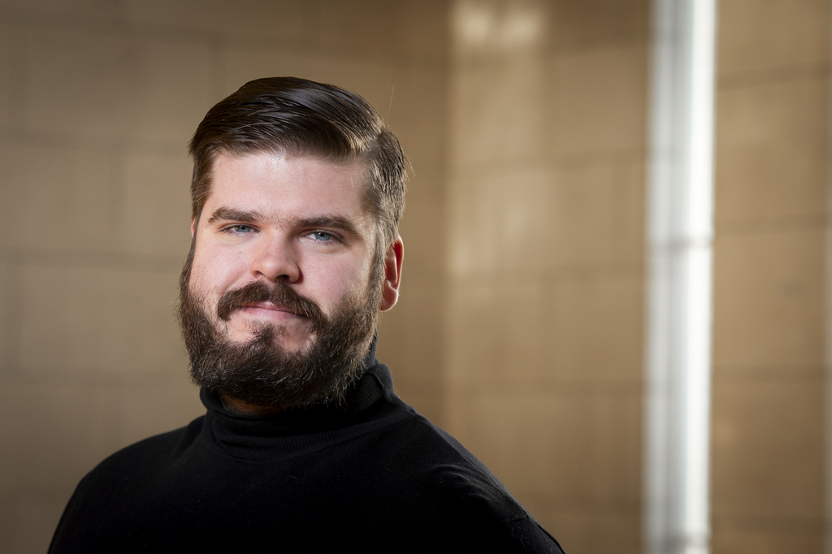

## Contact Info

- brynjolfur@hi.is
- bggj.is | metill.is
- github.com/bgautijonsson
- +354 8240872

## Skills

- Experienced in data analysis and statistical learning models
- Full experience with hierarchical Bayesian modelling.
- Highly skilled in R, STAN, Python and LaTeX
- Fully fluent in English and Norwegian
- Experienced public speaker

## Disclaimer

Last updated on 2025-01-13.

# Main

## Brynjólfur Gauti Guðrúnar Jónsson

### PhD Student of Statistics at the University of Iceland

I am a PhD student of statistics at the University of Iceland, researching spatially distributed extreme rainfall and methods for modeling data-level dependence using copulas. Prior to this, I have worked extensively with Bayesian hierarchical models, having applied them to forecasting parliamentary elections and age-dependent mortality as well as the modeling of COVID-19 disease spread in Iceland during the pandemic. I also manage metill.is, an Icelandic website where I use official data to inform the discourse on current matters.

## Education

### University of Iceland

PhD in Statistics

Reykjavík, Iceland

2027 (est)

Subject: Improved 21st century projections of sub-daily extreme precipitation by spatio-temporal recalibration

### University of Iceland

M.S. in Statistics

Reykjavík, Iceland

2020

Thesis: [Continuous Categories and Age-Specific Mortality Rates: An application of Gaussian process priors to the Lee-Carter model](https://skemman.is/handle/1946/37139)

### University of Iceland

B.S. in Psychology

Reykjavík, Iceland

2018

Thesis: [Up high, down low, too slow: Effects of nature on directed attention differ between high and low spatial frequencies.](https://skemman.is/handle/1946/30572) Results were presented at the Biomedical and Health Sciences Conference at the University of Iceland.

## Academic Experience

### StanCon 2024

Oxford University

Oxford, England

2024

- I presented my research and talked about modeling with copulas in Stan [Presentation slides](https://bggj.is/stancon24/presentation)

### Royal Statistical Society 2024 International Conference

Doubletree Brighton Metropole

Brighton, England

2024

- I gave a talk on my PhD research into developing Gaussian copulas for large spatial fields. [Presentation slides](https://bggj.is/rss24/presentation)

### PhD Student of Statistics

University of Iceland

Reykjavík, Iceland

2022 - present

- Researching improved 21st century projections of sub-daily extreme precipitation and how hierarchical Bayesian spatio-temporal models can be applied to bias-correct simulations from convection-permitting climate models using observed meteorological data.

### Statistician

The Icelandic Heart Association

Reykjavík, Iceland

2018 - 2022

- High-dimensional statistical modeling of the effects of serum levels of proteins on heart failure and other outcomes.

### Statistician

Directorate of Health

Reykjavík, Iceland

2020 - 2020

- Designed and implemented a Bayesian hierarchical generalized logistic growth model for short-term predictions of diagnosed cases at the start of the COVID19 pandemic.

### Graduate Research Assistant

The Science Institute, University of Iceland

Reykjavík, Iceland

2019

- Performed preliminary research related to my MSc thesis and presented results at the 2019 Nordic Demographic Symposium in Reykjavík

## Professional Experience

### Data Scientist

Lucinity

Reykjavík, Iceland

2023 - 2024

- Exploring the use of privacy-enhancing technologies, machine learning and network analysis for detecting money laundering activities
- Graph neural networks, federated learning, simulating structured large-scale graph data

### Statistician

The Icelandic Heart Association

Reykjavík, Iceland

2018 - 2022

- High-dimensional statistical modeling of the effects of serum levels of proteins on heart failure and other outcomes.
- Diverse data analysis projects to help with publications
- Writing software that helps coworkers with their reasearch

### Statistical Consultant

The Statistical Consulting Center, School of Health Sciences, University of Iceland

Reykjavík, Iceland

2018 - 2021

- Assisted graduate students and academic researchers with data analysis and statistical testing
- Wrote methods chapters for research articles
- Did power calculations and helped plan methodology before data was gathered

### Statistician

Directorate of Health

Reykjavík, Iceland

2020 - 2020

- Designed and implemented a Bayesian hierarchical generalized logistic growth model for short-term predictions of diagnosed cases at the start of the COVID19 pandemic.
- High speed data analysis used to gather actionable intelligence presented via interpretable graphics, tables and text
- [Designed and developed a detailed dashboard](http://covid.rhi.hi.is/shiny/dashboard/)

### Researcher

Icelandic Center for Research - RANNÍS

Reykjavík, Iceland

2018 - 2018

- Designed and planned a research project and applied for funding
- Developed personalized risk calculator to predict patients’ risk of 30-day readmittance to psychiatric wards
- One of five projects nominated for the President’s Innovation Award
- Results were presented at the Biomedical and Health Sciences Conference at the University of Iceland.

## Teaching Experience

### Statistical Consulting

Teacher

University of Iceland, Reykjavík, Iceland

2020 - present

### Applied Data Analysis

Teacher

University of Iceland, Reykjavík, Iceland

2020 - present

### R Programming

Teacher

University of Iceland, Reykjavík, Iceland

2019 - present

### Survival Analysis

Teaching assistant

University of Iceland, Reykjavík, Iceland

2019 - 2020